# Part I - (Dataset Exploration Title)

# Question 1: What is the distribution of Borrower APR?

```python
df1["BorrowerAPR"].isnull().sum()
```

```
25
```

```python
df1 = df1.dropna(subset=["BorrowerAPR"])
```

```python
df1["BorrowerAPR"].isnull().sum()
```

```
0
```

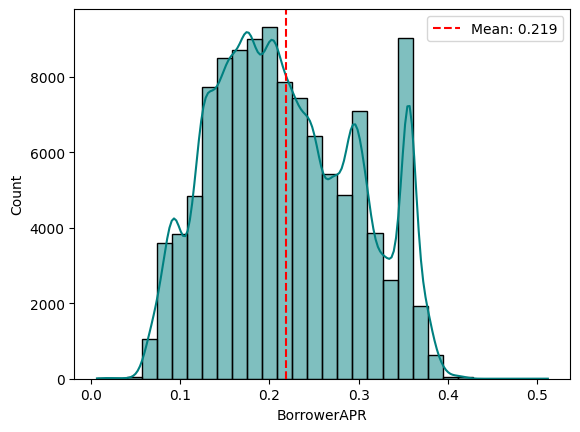

```python
mean_apr = df1['BorrowerAPR'].mean()

sns.histplot(df1['BorrowerAPR'], bins=30, kde=True, color='teal')
plt.axvline(mean_apr, color='red', linestyle='--', label=f'Mean: {mean_apr:.3f}')
plt.legend()
```

# Question 2: What is the distribution of Income Range?

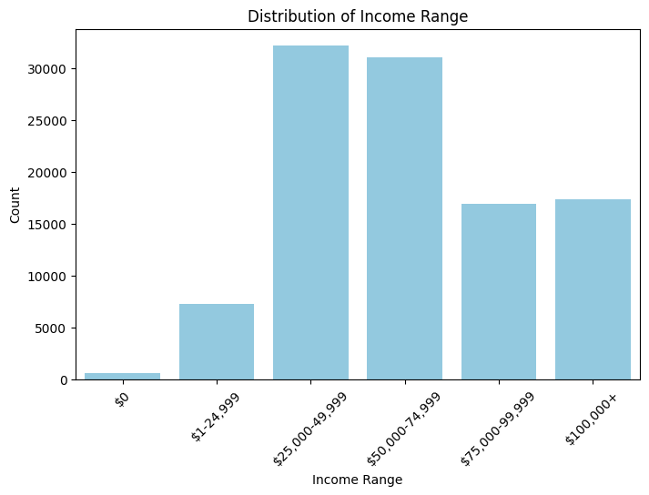

```python
income_order = ["$0", "$1-24,999", "$25,000-49,999", "$50,000-74,999", "$75,000-99,999", "$100,000+"]
df1['IncomeRange'] = pd.Categorical(df1['IncomeRange'], categories=income_order, ordered=True)

plt.figure(figsize=(8, 5))
sns.countplot(data=df1, x='IncomeRange', order=income_order, color='skyblue')
plt.title('Distribution of Income Range')
plt.xlabel('Income Range')
plt.ylabel('Count')
plt.xticks(rotation=45)
plt.show()
```

### Discuss the distribution(s) of your variable(s) of interest. Were there any unusual points? Did you need to perform any transformations?

For IncomeRange, as an ordinal variable, I converted it to an ordered categorical type to preserve the logical order of income brackets. The distribution was consistent and reasonable

## Bivariate Exploration

> In this section, investigate relationships between pairs of variables in your data. Make sure the variables that you cover here have been introduced in some fashion in the previous section (univariate exploration).

> **Rubric Tip**: This part (Bivariate Exploration) should include at least one scatter plot, one box plot, and at least one clustered bar chart or heat map.

# How does the Borrower APR vary with the Prosper Rating (Alpha)?

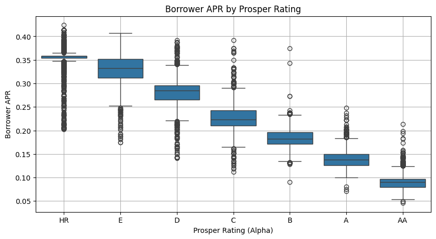

```python
plt.figure(figsize=(10, 5))
order = ['HR', 'E', 'D', 'C', 'B', 'A', 'AA']
sns.boxplot(data=df1, x='ProsperRating (Alpha)', y='BorrowerAPR', order=order)
plt.title('Borrower APR by Prosper Rating')
plt.xlabel('Prosper Rating (Alpha)')
plt.ylabel('Borrower APR')
plt.grid(True)
plt.show()
```

# Is there a relationship between the Borrower Rate and the Debt-to-Income Ratio?

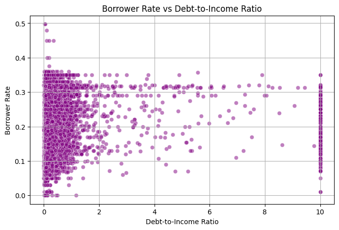

```python
plt.figure(figsize=(8, 5))
sns.scatterplot(data=df1, x='DebtToIncomeRatio', y='BorrowerRate', alpha=0.5, color='purple')
plt.title('Borrower Rate vs Debt-to-Income Ratio')
plt.xlabel('Debt-to-Income Ratio')
plt.ylabel('Borrower Rate')
plt.grid(True)
plt.show()
```

# How does Loan Status vary across different Income Ranges?

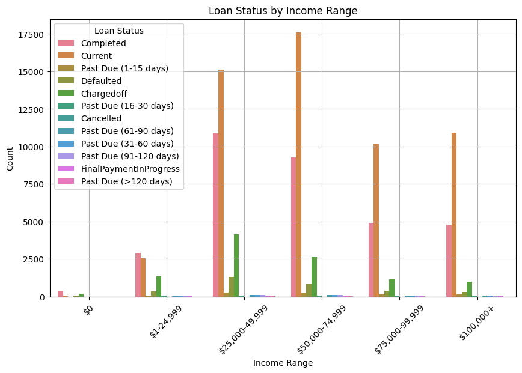

```python
plt.figure(figsize=(10, 6))
sns.countplot(data=df1, x='IncomeRange', hue='LoanStatus', order=income_order)
plt.title('Loan Status by Income Range')
plt.xlabel('Income Range')
plt.ylabel('Count')
plt.xticks(rotation=45)
plt.legend(title='Loan Status')
plt.grid(True)
plt.show()
```

### Talk about some of the relationships you observed in this part of the investigation. How did the feature(s) of interest vary with other features in the dataset?

Borrower APR vs Prosper Rating: Borrower APR decreases significantly as Prosper Rating improves from HR (high risk) to AA (low risk). This suggests that borrowers with higher creditworthiness are offered lower interest rates.

Loan Status vs Income Range: Higher income borrowers tend to have more Current or Completed loans, while lower income groups have a higher presence of Chargedoff or Defaulted loans. This suggests a link between income and ability to repay.

### Did you observe any interesting relationships between the other features (not the main feature(s) of interest)?

Income Range and Loan Status: As observed in the clustered bar chart, borrowers in higher income brackets are more likely to complete or remain current on their loans.

## Multivariate Exploration

Question: Facet plot - APR by Income Range and Loan Status

> Create plots of three or more variables to investigate your data even further. Make sure that your investigations are justified, and follow from your work in the previous sections.

> **Rubric Tip**: This part (Multivariate Exploration) should include at least one Facet Plot, and one Plot Matrix or Scatterplot with multiple encodings.

> **Rubric Tip**: Think carefully about how you encode variables. Choose appropriate color schemes, markers, or even how Facets are chosen. Also, do not overplot or incorrectly plot ordinal data.

# How does Borrower APR vary by Loan Status across different Income Ranges?

[figure not shown]

```python
income_order = ["$0", "$1-24,999", "$25,000-49,999", "$50,000-74,999", "$75,000-99,999", "$100,000+"]
df1['IncomeRange'] = pd.Categorical(df1['IncomeRange'], categories=income_order, ordered=True)
g = sns.FacetGrid(data=df1, col='IncomeRange', col_wrap=3, height=4)
g.map_dataframe(sns.boxplot, x='LoanStatus', y='BorrowerAPR')
g.set_xticklabels(rotation=45)
g.fig.subplots_adjust(top=0.9)
g.fig.suptitle('APR by Loan Status across Income Ranges')
plt.show()
```

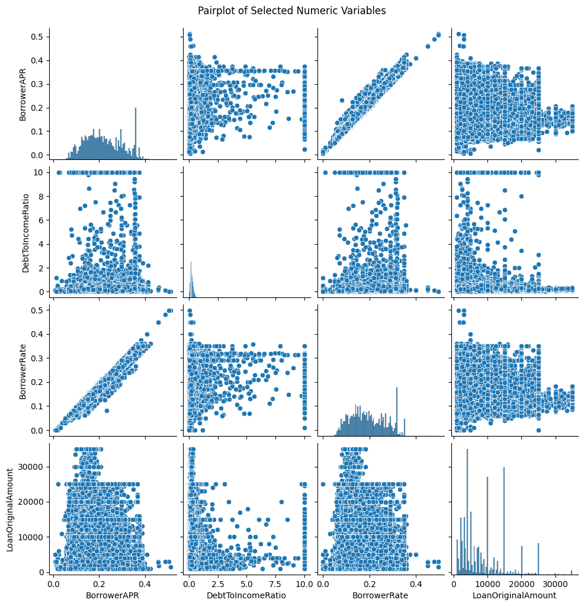

```python
sns.pairplot(df1[['BorrowerAPR', 'DebtToIncomeRatio', 'BorrowerRate', 'LoanOriginalAmount']])
plt.suptitle('Pairplot of Selected Numeric Variables', y=1.02)
plt.show()
```

### Talk about some of the relationships you observed in this part of the investigation. Were there features that strengthened each other in terms of looking at your feature(s) of interest?

The Pairplot showed a strong positive correlation between BorrowerAPR and BorrowerRate, reinforcing the idea that both represent borrowing costs and reflect similar risk factors.

## Conclusions

The majority of loans are either Completed or Current.

Borrower APR is strongly related to Prosper Rating — higher-rated borrowers receive lower APRs.

> **Rubric Tip**: Create a list of summary findings to make it easy to review.

> Remove all Tips mentioned above, before you convert this notebook to PDF/HTML.

> At the end of your report, make sure that you export the notebook as an html file from the `File > Download as... > HTML or PDF` menu. Make sure you keep track of where the exported file goes, so you can put it in the same folder as this notebook for project submission. Also, make sure you remove all of the quote-formatted guide notes like this one before you finish your report!

```python
df1.to_csv('clean_dataset.csv', index=False)
```